# HW4-Predictive regression modeling with R

misken

February 9, 2018

## Step 1 - Familiarize yourself with the data and the assignment

In this assignment you'll build some predictive regression models with R on a dataset containing inpatient discharges from hospitals in New York.

The version of this data that we'll be using is from a Kaggle dataset. See https://www.kaggle.com/jonasalmeida/2015-deidentified-ny-inpatient-discharge-sparcs. Unfortunately, the column metadata wasn't posted. However, since this is a publicly available dataset, we can visit the source at https://health.data.ny.gov/Health/Hospital-Inpatient-Discharges-SPARCS-De-Identified/82xm-y6g8.

If you scroll down on that page you'll find descriptions of the columns (click the little Show All link to display the entire list).

Most of the fields are self-explanatory. You'll notice that there are several sets of diagnosis and procedure codes. A few definitions are helpful.

### DRG - Diagnosis Related Groups

DRGs are a coding system developed in the 1980s that form the basis of how hospitals are reimbursed from Medicare (US Govt) or private insurers. After a patient is discharged from the hospital, a program known as a *DRG grouper* uses information such as diagnosis and procedure codes (ICD-9-CM) to assign a DRG to the patient. A full list of the over 900 DRGs can be found at:

https://www.cms.gov/Research-Statistics-Data-and-Systems/Statistics-Trends-and-Reports/MedicareFeeforSvcPartsAB/downloads/DRGdesc08.pdf

In that list you'll see that MDC (Medical Diagnostic Category) is simply a grouping of DRGs.

### CCS - Clinical Classification System

The [CCS](https://www.hcup-us.ahrq.gov/toolssoftware/ccs/ccs.jsp) system was developed by the [Agency for Healthcare Research and Quality (AHRQ)](https://www.ahrq.gov/) to provide a classification system better suited to healthcare research. There are CCS diagnosis codes and CCS procedure codes. From their website:

> The Clinical Classifications Software (CCS) for ICD-9-CM is a diagnosis and procedure categorization scheme that can be employed in many types of projects analyzing data on diagnoses and procedures. CCS is based on the International Classification of Diseases, 9th Revision, Clinical Modification (ICD-9-CM), a uniform and standardized coding system. The ICD-9-CM's multitude of codes - over 14,000 diagnosis codes and 3,900 procedure codes - are collapsed into a smaller number of clinically meaningful categories that are sometimes more useful for presenting descriptive statistics than are individual ICD-9-CM codes.

As we did in class, you'll be creating an R Markdown document to do the analysis as well as to document the steps you did (and answer some questions I'll throw at you).

You'll notice a few "Hacker Extra" tasks thrown in. These are for those of you who want to go a little above and beyond and attempt some more challenging tasks.

## Step 2 - Create a new R Markdown document

Save this file as a new R Markdown document and name it something that includes your last name in the filename. Save it into the same folder as this file.

## Step 3 - Create project and load data

Create an R Studio project in the current folder (the one containing this file). You'll notice that there is a folder named **data**. Inside of it you'll find the data file for this assignment:

- **ipd_resp.RData**

The full dataset contains over two million records and is available as a CSV file from Kaggle. I did a little data filtering and cleaning to create a subset to use for this regression assignment. Specifically, I did the following:

- used dplyr to filter records so that we were just working with `APR MDC Code` == 4. These are patients having respiratory related diagnoses.
- a bunch of fields were read in as `chr` and I changed them to factors using `as.factor`.
- There were some fields we don't need and they were dropped.
- Just as in HW1, I cleaned up the charges and costs fields that got interpreted as `chr` because of the leading dollar sign. Now they are numeric.
- Modified some field names to make them easier to work with.

See the data prep script for all the details. You do **NOT** need to run the data prep script. I'm just including it so you can see a typical data prep script.

### Load the data

```r
load("./data/ipd_resp.RData")
#str(ipd_resp)
```

## Step 4 - Partition into training and test sets

Just run this chunk to create training and test datasets. This way we'll all be working with the same datasets. Notice that the test set is 30% of the full dataset.

```r
set.seed(1828)
sample_size <- ceiling(0.30 * nrow(ipd_resp))
testrecs <- sample(nrow(ipd_resp),sample_size)
ipd_test <- ipd_resp[testrecs,]
ipd_train <- ipd_resp[-testrecs,]  # Negative in front of vector means "not in"
rm(ipd_resp) # No sense keeping a copy of the entire dataset around
```

## Step 5 - EDA on training data

Now start with some EDA on the training dataset`ipd_train`. The test data will only get used after building models and want to compare their predictive abilities.

You'll notice that `ipd_train` contains a few numeric fields and many factors (categorical data). You are free to use any of these fields in your regression models to predict `Total_Charges`.

Start by using things like ggplot2 and dplyr to explore the training dataset. You can use other packages as well. Your goal is to gain a general understanding of the variables and perhaps uncover some useful relationships that you can use in your regression models.

**NOTE: In the data prep phase I made sure there were no NA values in the data frames that we are using for this assignment. So, no need to worry about that.**

```r
library(dplyr)
```

```r
library(ggplot2)
```

```r
summary(ipd_train)
```

```
##      Health_Service_Area  Hospital_County   Facility_Id
##  New York City :59355    Manhattan:17112   1169   :  3769
##  Long Island   :18906    Kings    :14286   1464   :  2655
##  Hudson Valley :14989    Bronx    :13883   1172   :  2517
##  Capital/Adiron:11629    Queens   :10931   1178   :  2341
##  Central NY    :10770    Suffolk  : 9603   1458   :  2091
##  Western NY    :10456    Nassau   : 9303   413    :  2013
##  (Other)       :11215    (Other)  :62202   (Other):121934
##                                                         Facility_Name
##  Montefiore Medical Center - Henry & Lucy Moses Div            :  3769
##  New York Presbyterian Hospital - Columbia Presbyterian Center :  2655
##  Lincoln Medical & Mental Health Center                        :  2517
##  Bronx-Lebanon Hospital Center - Concourse Division            :  2341
##  New York Presbyterian Hospital - New York Weill Cornell Center:  2091
##  Good Samaritan Hospital Medical Center                        :  2013
##  (Other)                                                       :121934
##        Age_Group        ZipCode      Gender
##  0 to 17    :18955   112    :16184   F:72465
##  18 to 29   : 4410   104    :15118   M:64855
##  30 to 49   :13174   117    :10422   U:    0
##  50 to 69   :44726   100    : 8879
##  70 or Older:56055   113    : 6190
##                      115    : 4771
##                      (Other):75756
##                      Race                   Ethnicity
##  Black/African American:26759   Multi-ethnic     :   533
##  Multi-racial          : 1248   Not Span/Hispanic:114997
##  Other Race            :28283   Spanish/Hispanic : 16107
##  White                 :81030   Unknown          :  5683
##
##
##
##  Length_of_Stay        Type_of_Admission
##  Min.   :  1.000   Elective     :  7833
##  1st Qu.:  2.000   Emergency    :123327
##  Median :  4.000   Newborn      :    15
##  Mean   :  5.591   Not Available:    56
##  3rd Qu.:  7.000   Trauma       :   391
##  Max.   :119.000   Urgent       :  5698
##
```

[output cut: 41 more lines]

```
##  Extreme :14310               Extreme : 9920
##  Major   :46752               Major   :36936
##  Minor   :23375               Minor   :50734
##  Moderate:52883               Moderate:39730
##  unknown :    0
##
##
##                  Payment_Typology_1 Total_Charges      Total_Costs
##  Medicare                 :72837    Min.   :      1   Min.   :     0.6
##  Medicaid                 :34848    1st Qu.:  13190   1st Qu.:  5283.6
##  Private Health Insurance :12315    Median :  24485   Median :  8998.8
##  Blue Cross/Blue Shield   :10478    Mean   :  41551   Mean   : 15527.7
##  Self-Pay                 : 3150    3rd Qu.:  46436   3rd Qu.: 16499.2
##  Managed Care, Unspecified: 1292    Max.   :2691248   Max.   :689872.8
##  (Other)                  : 2400
```

Now, it's your turn ...

## Step 6 - Building and evaluation of predictive models

Now that you know a little more about the data, it's time to start building a few predictive models for `Total_Charges`. The error metric that we will use to evaluate the models (both for fit and for predictions) is **median absolute deviation** (MAD). This is nothing more than the median of the absolute value of the residuals for a fitted model.

**QUESTION:** What might be an advantage of using median absolute deviation instead of mean absolute deviation?

**The median absolute deviation is more robust than the mean absolute deviation, in the sense that the former is less susceptible to the influence of outlier values in the residuals.**

Obviously we want models with lower MAD values. Our ultimate goal is to create a model that predicts well on the test dataset, `ipd_test`.

### Null model

It's always a good idea to start out with what we call the *null model*. This is the simplest possible model and one that other models better be able to beat. For this regression problem, the null model is simply a regression model that just has a y-intercept. If you remember some of your statistics, you won't be surprised that the best fit value for the y-intercept in this case is the mean of the response variable, `Total_Charges`.

```r
charges_lm0 <- lm(Total_Charges ~ 1, data = ipd_train)
summary(charges_lm0)
```

```
##
## Call:
## lm(formula = Total_Charges ~ 1, data = ipd_train)
##
## Residuals:
##     Min      1Q  Median      3Q     Max
##  -41550  -28361  -17067    4885 2649697
##
## Coefficients:
##             Estimate Std. Error t value Pr(>|t|)
## (Intercept)    41551        172   241.5   <2e-16 ***
## ---
## Signif. codes:  0 '***' 0.001 '**' 0.01 '*' 0.05 '.' 0.1 ' ' 1
##
## Residual standard error: 63750 on 137319 degrees of freedom
```

```r
# Compute the MAD value
median(abs(charges_lm0$residuals))
```

```
## [1] 24376.3
```

It's not hard to create regression models with smaller MAD values than this. :)

Just to give you a benchmark, I built a model on the training set that had a MAD value of 7270.340. Again, this is just the median of the absolute values of the residuals of the fitted model. Later when I used this model on the test data, I got a MAD of ... well, I'll tell you a little later.

### Model building

Using the information you've gained from reading about the data and doing some EDA, build several regression models and compute the MAD from each. Summarize your results in terms of which model or models appear to fit well.

```r
charges_lm1 <- lm(Total_Charges ~ APR_Severity_of_Illness_Desc + Length_of_Stay, data = ipd_train)
summary(charges_lm1)
```

```
##
## Call:
## lm(formula = Total_Charges ~ APR_Severity_of_Illness_Desc + Length_of_Stay,
##     data = ipd_train)
##
## Residuals:
##     Min      1Q  Median      3Q     Max
## -622977  -10634   -1476    7567 1923182
##
## Coefficients:
##                                       Estimate Std. Error t value Pr(>|t|)
## (Intercept)                           24110.63     387.28   62.26   <2e-16
## APR_Severity_of_Illness_DescMajor    -24593.67     383.15  -64.19   <2e-16
## APR_Severity_of_Illness_DescMinor    -22593.65     444.16  -50.87   <2e-16
## APR_Severity_of_Illness_DescModerate -23915.94     392.71  -60.90   <2e-16
## Length_of_Stay                         6952.85      16.73  415.52   <2e-16
##
## (Intercept)                          ***
## APR_Severity_of_Illness_DescMajor    ***
## APR_Severity_of_Illness_DescMinor    ***
## APR_Severity_of_Illness_DescModerate ***
## Length_of_Stay                       ***
## ---
## Signif. codes:  0 '***' 0.001 '**' 0.01 '*' 0.05 '.' 0.1 ' ' 1
##
## Residual standard error: 38680 on 137315 degrees of freedom
## Multiple R-squared:  0.6318, Adjusted R-squared:  0.6318
## F-statistic: 5.89e+04 on 4 and 137315 DF,  p-value: < 2.2e-16
```

```r
median(abs(charges_lm1$residuals))
```

```
## [1] 9175.867
```

```r
charges_lm2 <- lm(Total_Charges ~ APR_Risk_of_Mortality + Length_of_Stay, data = ipd_train)
summary(charges_lm2)
```

```
##
## Call:
## lm(formula = Total_Charges ~ APR_Risk_of_Mortality + Length_of_Stay,
##     data = ipd_train)
##
## Residuals:
##     Min      1Q  Median      3Q     Max
## -640484  -10826   -1719    7345 1910673
##
## Coefficients:
##                                Estimate Std. Error t value Pr(>|t|)
## (Intercept)                    19943.05     443.58   44.96   <2e-16 ***
## APR_Risk_of_MortalityMajor    -19437.98     449.17  -43.27   <2e-16 ***
## APR_Risk_of_MortalityMinor    -18771.02     454.82  -41.27   <2e-16 ***
## APR_Risk_of_MortalityModerate -20632.84     455.31  -45.32   <2e-16 ***
## Length_of_Stay                  7108.71      16.51  430.69   <2e-16 ***
## ---
## Signif. codes:  0 '***' 0.001 '**' 0.01 '*' 0.05 '.' 0.1 ' ' 1
##
## Residual standard error: 38990 on 137315 degrees of freedom
## Multiple R-squared:  0.626,  Adjusted R-squared:  0.626
## F-statistic: 5.746e+04 on 4 and 137315 DF,  p-value: < 2.2e-16
```

```r
median(abs(charges_lm2$residuals))
```

```
## [1] 9223.995
```

```r
charges_lm3 <- lm(Total_Charges ~ APR_DRG_Desc + Length_of_Stay, data = ipd_train)
summary(charges_lm3)
```

```
##
## Call:
## lm(formula = Total_Charges ~ APR_DRG_Desc + Length_of_Stay, data = ipd_train)
##
## Residuals:
##     Min      1Q  Median      3Q     Max
## -591544   -9489   -1438    7274 1890939
##
## Coefficients:
##                                                                                   Estimate
## (Intercept)                                                                        2793.95
## APR_DRG_DescBone marrow transplant                                                47892.77
## APR_DRG_DescBPD & oth chronic respiratory diseases arising in perinatal period     -744.85
## APR_DRG_DescBronchiolitis & RSV pneumonia                                          -206.46
## APR_DRG_DescChronic obstructive pulmonary disease                                 -3165.41
## APR_DRG_DescCystic fibrosis - pulmonary disease                                   10490.42
## APR_DRG_DescExtensive procedure unrelated to principal diagnosis                  60332.52
## APR_DRG_DescHeart &/or lung transplant                                           418590.78
## APR_DRG_DescInterstitial & alveolar lung diseases                                  4542.29
## APR_DRG_DescMajor chest & respiratory trauma                                       4240.43
## APR_DRG_DescMajor respiratory & chest procedures                                  42967.08
## APR_DRG_DescMajor respiratory infections & inflammations                          -2258.99
## APR_DRG_DescModerately extensive procedure unrelated to principal diagnosis       39341.97
## APR_DRG_DescNonextensive procedure unrelated to principal diagnosis               18091.60
## APR_DRG_DescOther pneumonia                                                       -2573.72
## APR_DRG_DescOther respiratory & chest procedures                                  29786.73
## APR_DRG_DescOther respiratory diagnoses except signs, symptoms & minor diagnoses   2906.00
## APR_DRG_DescPulmonary embolism                                                     4921.42
## APR_DRG_DescRespiratory Failure                                                    2206.77
## APR_DRG_DescRespiratory malignancy                                                  343.00
## APR_DRG_DescRespiratory signs, symptoms & minor diagnoses                          1053.13
## APR_DRG_DescRespiratory system diagnosis w ventilator support 96+ hours           41225.71
## APR_DRG_DescTracheostomy w MV 96+ hours w extensive procedure or ECMO            225594.79
## APR_DRG_DescTracheostomy w MV 96+ hours w/o extensive procedure                  121802.72
## Length_of_Stay                                                                     6315.07
##                                                                                  Std. Error
## (Intercept)                                                                          296.76
## APR_DRG_DescBone marrow transplant                                                 12707.73
## APR_DRG_DescBPD & oth chronic respiratory diseases arising in perinatal period      2064.41
## APR_DRG_DescBronchiolitis & RSV pneumonia                                            570.29
```

[output cut: 90 more lines]

```
## APR_DRG_DescOther respiratory diagnoses except signs, symptoms & minor diagnoses ***
## APR_DRG_DescPulmonary embolism                                                   ***
## APR_DRG_DescRespiratory Failure                                                  ***
## APR_DRG_DescRespiratory malignancy
## APR_DRG_DescRespiratory signs, symptoms & minor diagnoses                        .
## APR_DRG_DescRespiratory system diagnosis w ventilator support 96+ hours          ***
## APR_DRG_DescTracheostomy w MV 96+ hours w extensive procedure or ECMO            ***
## APR_DRG_DescTracheostomy w MV 96+ hours w/o extensive procedure                  ***
## Length_of_Stay                                                                   ***
## ---
## Signif. codes:  0 '***' 0.001 '**' 0.01 '*' 0.05 '.' 0.1 ' ' 1
##
## Residual standard error: 35930 on 137295 degrees of freedom
## Multiple R-squared:  0.6823, Adjusted R-squared:  0.6823
## F-statistic: 1.229e+04 on 24 and 137295 DF,  p-value: < 2.2e-16
```

```r
median(abs(charges_lm3$residuals))
```

```
## [1] 8466.517
```

```r
#Model 1
```

```r
charges_lm4 <- lm(Total_Charges ~ Type_of_Admission + Length_of_Stay, data = ipd_train)
summary(charges_lm4)
```

```
##
## Call:
## lm(formula = Total_Charges ~ Type_of_Admission + Length_of_Stay,
##     data = ipd_train)
##
## Residuals:
##     Min      1Q  Median      3Q     Max
## -673606  -10788   -1342    7203 1910715
##
## Coefficients:
##                                 Estimate Std. Error t value Pr(>|t|)
## (Intercept)                     10491.16     454.96  23.059  < 2e-16 ***
## Type_of_AdmissionEmergency     -10486.00     457.21 -22.935  < 2e-16 ***
## Type_of_AdmissionNewborn       -40386.45   10133.38  -3.985 6.74e-05 ***
## Type_of_AdmissionNot Available   -794.68    5257.22  -0.151     0.88
## Type_of_AdmissionTrauma         10815.58    2031.44   5.324 1.02e-07 ***
## Type_of_AdmissionUrgent         -7935.85     682.56 -11.627  < 2e-16 ***
## Length_of_Stay                   7294.65      15.44 472.528  < 2e-16 ***
## ---
## Signif. codes:  0 '***' 0.001 '**' 0.01 '*' 0.05 '.' 0.1 ' ' 1
##
## Residual standard error: 39200 on 137313 degrees of freedom
## Multiple R-squared:  0.6218, Adjusted R-squared:  0.6218
## F-statistic: 3.763e+04 on 6 and 137313 DF,  p-value: < 2.2e-16
```

```r
median(abs(charges_lm4$residuals))
```

```
## [1] 9060.814
```

```r
 #Model 3
```

```r
charges_lm5 <- lm(Total_Charges ~ CCS_Dx_Desc + Length_of_Stay, data = ipd_train)
summary(charges_lm5)
```

```
##
## Call:
## lm(formula = Total_Charges ~ CCS_Dx_Desc + Length_of_Stay, data = ipd_train)
##
## Residuals:
##     Min      1Q  Median      3Q     Max
## -662531  -10524   -1061    7483 1919439
##
## Coefficients:
##                                                                                                   Estimate
## (Intercept)                                                                                        -517.19
## CCS_Dx_DescAllergic reactions                                                                     21655.62
## CCS_Dx_DescAspiration pneumonitis; food/vomitus                                                   -3412.43
## CCS_Dx_DescAsthma                                                                                   666.61
## CCS_Dx_DescBacterial infection; unspecified site                                                   4209.09
## CCS_Dx_DescBurns                                                                                  41335.28
## CCS_Dx_DescCancer of bronchus; lung                                                               15836.96
## CCS_Dx_DescCancer; other and unspecified primary                                                  39985.51
## CCS_Dx_DescCancer; other respiratory and intrathoracic                                            27385.58
## CCS_Dx_DescChronic obstructive pulmonary disease and bronchiectasis                               -4046.56
## CCS_Dx_DescComplication of device; implant or graft                                               97925.21
## CCS_Dx_DescComplications of surgical procedures or medical care                                   10821.98
## CCS_Dx_DescCrushing injury or internal injury                                                      9535.67
## CCS_Dx_DescCystic fibrosis                                                                        10726.95
## CCS_Dx_DescGangrene                                                                               24606.78
## CCS_Dx_DescImmunity disorders                                                                      1021.93
## CCS_Dx_DescImmunizations and screening for infectious disease                                     -6526.53
## CCS_Dx_DescInfluenza                                                                              -3455.12
## CCS_Dx_DescJoint disorders and dislocations; trauma-related                                       18336.79
## CCS_Dx_DescLung disease due to external agents                                                     9287.62
## CCS_Dx_DescMeningitis (except that caused by tuberculosis or sexually transmitted disease)        11010.30
## CCS_Dx_DescMiscellaneous disorders                                                                 -797.93
## CCS_Dx_DescMycoses                                                                                88039.33
## CCS_Dx_DescNeoplasms of unspecified nature or uncertain behavior                                   6749.98
## CCS_Dx_DescOpen wounds of head; neck; and trunk                                                   17300.50
## CCS_Dx_DescOther acquired deformities                                                             39249.61
## CCS_Dx_DescOther and unspecified benign neoplasm                                                  35329.61
## CCS_Dx_DescOther congenital anomalies                                                             35860.72
## CCS_Dx_DescOther fractures                                                                         5840.70
## CCS_Dx_DescOther infections; including parasitic                                                   5074.84
```

[output cut: 225 more lines]

```
## CCS_Dx_DescRespiratory failure; insufficiency; arrest (adult)                                    ***
## CCS_Dx_DescRheumatoid arthritis and related disease
## CCS_Dx_DescSecondary malignancies                                                                ***
## CCS_Dx_DescSexually transmitted infections (not HIV or hepatitis)
## CCS_Dx_DescSprains and strains
## CCS_Dx_DescSystemic lupus erythematosus and connective tissue disorders                          ***
## CCS_Dx_DescTuberculosis                                                                          ***
## CCS_Dx_DescViral infection                                                                       ***
## Length_of_Stay                                                                                   ***
## ---
## Signif. codes:  0 '***' 0.001 '**' 0.01 '*' 0.05 '.' 0.1 ' ' 1
##
## Residual standard error: 38720 on 137268 degrees of freedom
## Multiple R-squared:  0.6311, Adjusted R-squared:  0.631
## F-statistic:  4604 on 51 and 137268 DF,  p-value: < 2.2e-16
```

```r
median(abs(charges_lm5$residuals))
```

```
## [1] 9060.493
```

```r
# Model 2
```

Identify your top 3 models in terms of lowest MAD values to use in the next part in which you'll use them to make predictions on the test dataset.

**I quickly identified that Length_of_Stay lowered the MAD value more than any other explanatory variable alone, probably for the obvious reason that a longer stay = more potential charges. I tried to drive it down further by adding an additional explanatory variable, and found that APR_DRG_Desc(Diagnosis related group),CCS_Dx_Desc(diagnosis), and Type_of_Admission did so the most.**

**HACKER EXTRA:** Use k-crossfold validation to select your top 3 models.

### Model diagnostics

#### Scatterplots of actual vs fitted values

For your top 3 models, create a scatter plot showing actual vs fitted values of `Total_Charges`. Remember, it's often nice to "gather up" your results into a data frame to facilitate plotting. See the notes on comparing competing regression models. Here's what one of my scatterplots looks like.

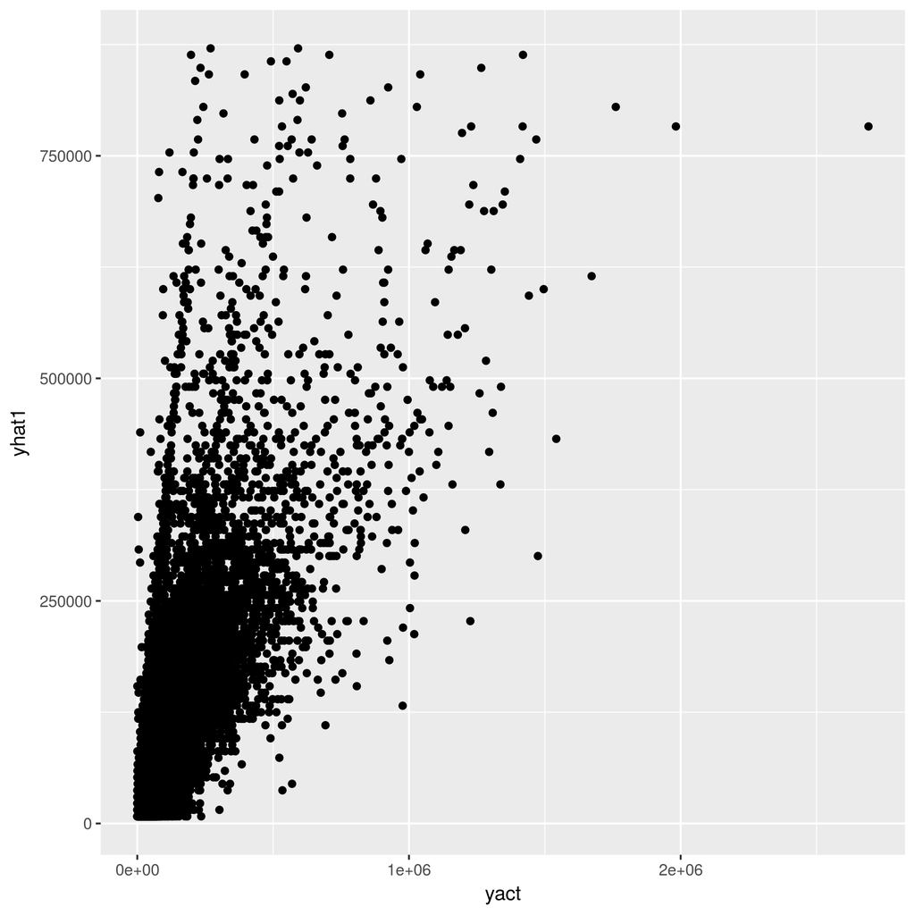

```r
modelTests <- data.frame(ActualTC=ipd_train[,"Total_Charges"],
                          LM1_TC=charges_lm3$fitted.values,
                          LM2_TC=charges_lm4$fitted.values,
                          LM3_TC=charges_lm5$fitted.values
                         )
```

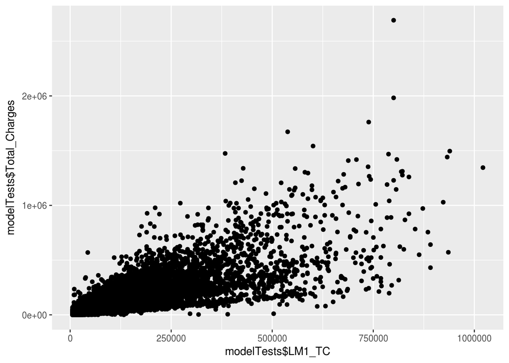

```r
ggplot(data=modelTests, aes(x=modelTests$LM1_TC,y=modelTests$Total_Charges)) + geom_point()
```

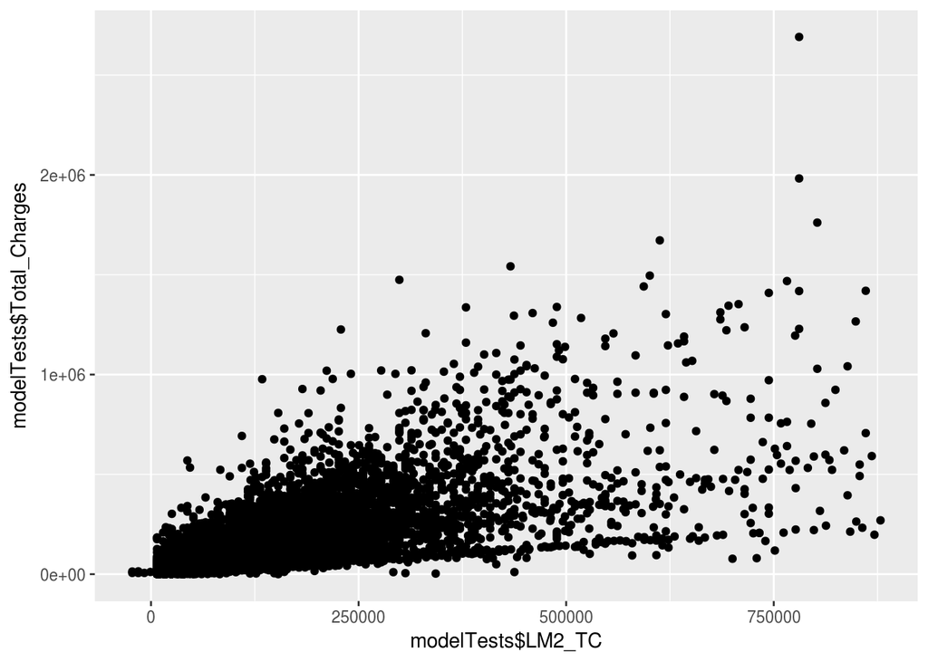

```r
ggplot(data=modelTests, aes(x=modelTests$LM2_TC,y=modelTests$Total_Charges)) + geom_point()
```

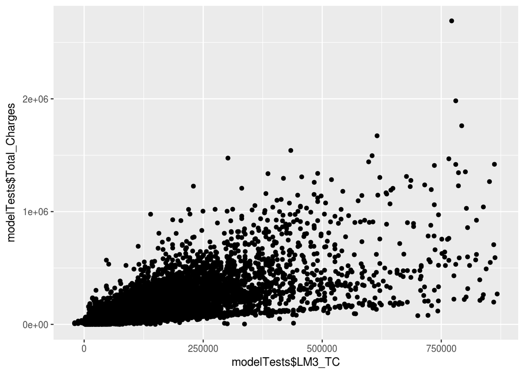

```r
ggplot(data=modelTests, aes(x=modelTests$LM3_TC,y=modelTests$Total_Charges)) + geom_point()
```

#### Normality of residuals

Create a histogram of the residuals for your top 3 models. You may have to tweak the axes scales to make a nice histogram.

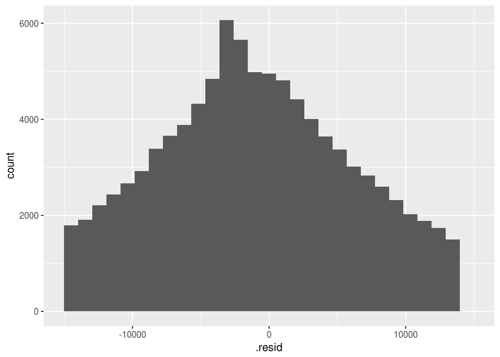

```r
ggplot(data=charges_lm3, aes(x=.resid)) + geom_histogram() + xlim(-15000, 15000)
```

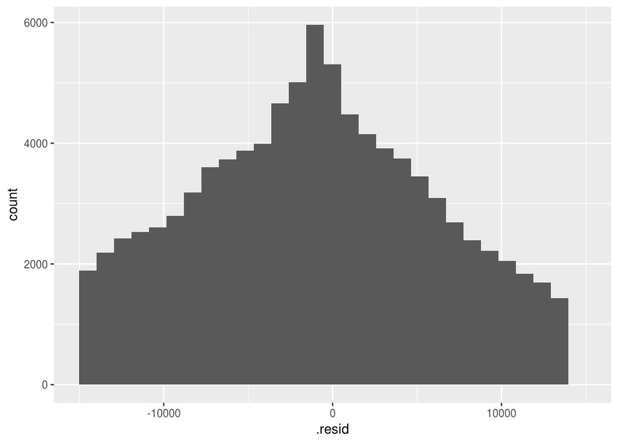

```r
ggplot(data=charges_lm4, aes(x=.resid)) + geom_histogram() + xlim(-15000, 15000)
```

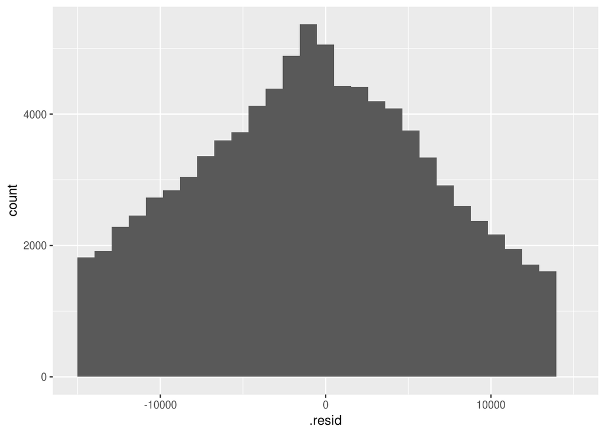

```r
ggplot(data=charges_lm5, aes(x=.resid)) + geom_histogram() + xlim(-15000, 15000)
```

#### Constant variance

Make an appropriate plot to check for constant variance (homeskedasticity) for your top model. Don't remember what kind of plot to make? See my notes on residual analysis or any intro stats book.

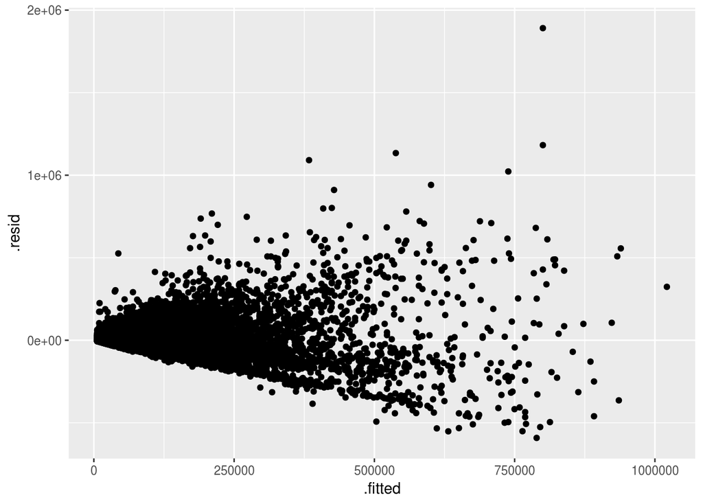

```r
ggplot(data=charges_lm3, aes(x=.fitted, y = .resid)) + geom_point()
```

### Make predictions for the test dataset

For each of your top 3 models, make predictions for `ipd_test`.

```r
predictLM3 <- predict(charges_lm3, ipd_test, interval = "prediction", se.fit = TRUE, na.rm = TRUE, level = 0.95)
```

```r
predictLM5 <- predict(charges_lm5, ipd_test, interval = "prediction", se.fit = TRUE, na.rm = TRUE, level = 0.95)
```

```r
predictLM4 <- predict(charges_lm4,  ipd_test, interval = "prediction", se.fit = TRUE, na.rm = TRUE, level = 0.95)
```

### Evaluate the predictions

Compute the MAD for each of the three models' predictions on the test data.

```r
median(abs(ipd_test$Total_Charges - predictLM3$fit)) #1st best model
```

```
## [1] 63029.02
```

```r
median(abs(ipd_test$Total_Charges - predictLM5$fit)) #2nd best model
```

```
## [1] 67990.49
```

```r
median(abs(ipd_test$Total_Charges - predictLM4$fit)) #3rd best model
```

```
## [1] 68970.52
```

HINT: Obviously you can't use the residuals (or errors) directly but will have to compute them. They are simply the difference between the actual values and your predicted values.

So, for the model I mentioned earlier that had a MAD of 7270.340 for the training data, the MAD on the test data was 7335.559. Notice that MAD for test is higher than MAD for train.

**QUESTION:** Do you think it's typical that MAD for test would be higher than MAD for train? Why or why not?

**In hindsight, it seems like this should usually be the case. The training data set is typically created to fit the parameters of the model, so it will naturally perform better.**

**QUESTION:** Which of your top 3 models had the lowest MAD for the test data?

**My top performing model for the training data set still had a lower MAD than the other two**

**QUESTION:** How do the MAD values for the test data compare to the MAD values for the training data?

**I was led to believe that the models I created for the training data set would be good fits for the test data, since the MAD values calculated for the training data were relatively low. If the MAD values I computed for the test data were computed correctly, this leads me to conclude that the models, in actuality, have very poor predictive power. In hindsight I should have taken into account the fact that the training dataset generally produces overly positive results and added additional explanatory variables to my models.**

Finally, create some sort of plot which shows the MAD values for both train and test for your top 3 models. One plot.

```r
MAD_1 <- median(abs(charges_lm3$residuals))
MAD_2 <- median(abs(charges_lm5$residuals))
MAD_3 <- median(abs(charges_lm4$residuals))
MAD_4 <- median(abs(ipd_test$Total_Charges - predictLM3$fit))
MAD_5 <- median(abs(ipd_test$Total_Charges - predictLM5$fit))
MAD_6 <- median(abs(ipd_test$Total_Charges - predictLM4$fit))
```

```r
MADS = c(MAD_1, MAD_2, MAD_3, MAD_4, MAD_5, MAD_6)
```

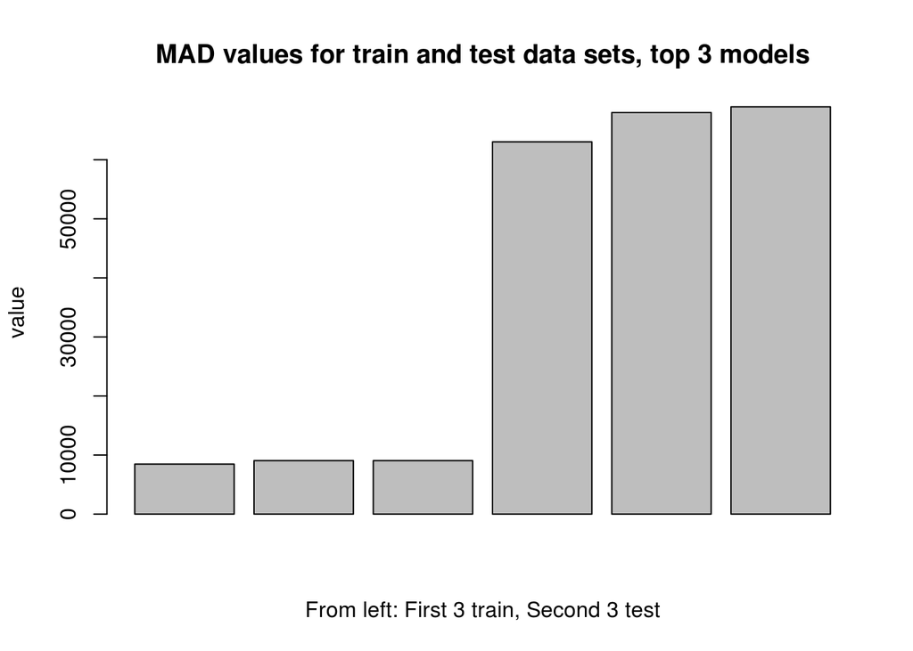

```r
barplot(MADS, main = "MAD values for train and test data sets, top 3 models", xlab = "From left: First 3 train, Second 3 test", ylab = "value")
```

### Your top model

Show your top performing model and discuss whether the model appears to make sense in terms of the variables included. Why did you choose the variables you did?

```r
charges_lm3 <- lm(Total_Charges ~ APR_DRG_Desc + Length_of_Stay, data = ipd_train)
summary(charges_lm3)
```

```
##
## Call:
## lm(formula = Total_Charges ~ APR_DRG_Desc + Length_of_Stay, data = ipd_train)
##
## Residuals:
##     Min      1Q  Median      3Q     Max
## -591544   -9489   -1438    7274 1890939
##
## Coefficients:
##                                                                                   Estimate
## (Intercept)                                                                        2793.95
## APR_DRG_DescBone marrow transplant                                                47892.77
## APR_DRG_DescBPD & oth chronic respiratory diseases arising in perinatal period     -744.85
## APR_DRG_DescBronchiolitis & RSV pneumonia                                          -206.46
## APR_DRG_DescChronic obstructive pulmonary disease                                 -3165.41
## APR_DRG_DescCystic fibrosis - pulmonary disease                                   10490.42
## APR_DRG_DescExtensive procedure unrelated to principal diagnosis                  60332.52
## APR_DRG_DescHeart &/or lung transplant                                           418590.78
## APR_DRG_DescInterstitial & alveolar lung diseases                                  4542.29
## APR_DRG_DescMajor chest & respiratory trauma                                       4240.43
## APR_DRG_DescMajor respiratory & chest procedures                                  42967.08
## APR_DRG_DescMajor respiratory infections & inflammations                          -2258.99
## APR_DRG_DescModerately extensive procedure unrelated to principal diagnosis       39341.97
## APR_DRG_DescNonextensive procedure unrelated to principal diagnosis               18091.60
## APR_DRG_DescOther pneumonia                                                       -2573.72
## APR_DRG_DescOther respiratory & chest procedures                                  29786.73
## APR_DRG_DescOther respiratory diagnoses except signs, symptoms & minor diagnoses   2906.00
## APR_DRG_DescPulmonary embolism                                                     4921.42
## APR_DRG_DescRespiratory Failure                                                    2206.77
## APR_DRG_DescRespiratory malignancy                                                  343.00
## APR_DRG_DescRespiratory signs, symptoms & minor diagnoses                          1053.13
## APR_DRG_DescRespiratory system diagnosis w ventilator support 96+ hours           41225.71
## APR_DRG_DescTracheostomy w MV 96+ hours w extensive procedure or ECMO            225594.79
## APR_DRG_DescTracheostomy w MV 96+ hours w/o extensive procedure                  121802.72
## Length_of_Stay                                                                     6315.07
##                                                                                  Std. Error
## (Intercept)                                                                          296.76
## APR_DRG_DescBone marrow transplant                                                 12707.73
## APR_DRG_DescBPD & oth chronic respiratory diseases arising in perinatal period      2064.41
## APR_DRG_DescBronchiolitis & RSV pneumonia                                            570.29
```

[output cut: 90 more lines]

```
## APR_DRG_DescOther respiratory diagnoses except signs, symptoms & minor diagnoses ***
## APR_DRG_DescPulmonary embolism                                                   ***
## APR_DRG_DescRespiratory Failure                                                  ***
## APR_DRG_DescRespiratory malignancy
## APR_DRG_DescRespiratory signs, symptoms & minor diagnoses                        .
## APR_DRG_DescRespiratory system diagnosis w ventilator support 96+ hours          ***
## APR_DRG_DescTracheostomy w MV 96+ hours w extensive procedure or ECMO            ***
## APR_DRG_DescTracheostomy w MV 96+ hours w/o extensive procedure                  ***
## Length_of_Stay                                                                   ***
## ---
## Signif. codes:  0 '***' 0.001 '**' 0.01 '*' 0.05 '.' 0.1 ' ' 1
##
## Residual standard error: 35930 on 137295 degrees of freedom
## Multiple R-squared:  0.6823, Adjusted R-squared:  0.6823
## F-statistic: 1.229e+04 on 24 and 137295 DF,  p-value: < 2.2e-16
```

```r
median(abs(charges_lm3$residuals))
```

```
## [1] 8466.517
```

**In addition to daily stay costs, I added the diagnosis-related group as an explanatory variable. Since the DRG determines how much the hospital gets reimbursed by Medicare, any excess cost not covered would be transferred to the patient. In hindsight, I should have included many more explanatory variables, perhaps 10 or more.**

It will be interesting to compare the best models that everyone finds.

Later we'll learn more techniques that will likely allow us to beat simple linear models.